# Risk Factor Analysis

## Outcome Variable

**Outcome Variable:** ever_wasted

## Predictor Variables

**Intervention Variable:** hfoodsec

**Adjustment Set:**

unadjusted

## Stratifying Variables

The analysis was stratified on these variable(s):

- agecat
- studyid
- country

## Data Summary

| agecat | studyid | country | hfoodsec | ever_wasted | n_cell | n |
| --- | --- | --- | --- | --- | --- | --- |
| 0-24 months | ki0047075b-MAL-ED | BANGLADESH | Food Secure | 0 | 105 | 194 |
| 0-24 months | ki0047075b-MAL-ED | BANGLADESH | Food Secure | 1 | 56 | 194 |
| 0-24 months | ki0047075b-MAL-ED | BANGLADESH | Mildly Food Insecure | 0 | 3 | 194 |
| 0-24 months | ki0047075b-MAL-ED | BANGLADESH | Mildly Food Insecure | 1 | 1 | 194 |
| 0-24 months | ki0047075b-MAL-ED | BANGLADESH | Food Insecure | 0 | 19 | 194 |
| 0-24 months | ki0047075b-MAL-ED | BANGLADESH | Food Insecure | 1 | 10 | 194 |
| 0-24 months | ki0047075b-MAL-ED | BRAZIL | Food Secure | 0 | 3 | 129 |
| 0-24 months | ki0047075b-MAL-ED | BRAZIL | Food Secure | 1 | 0 | 129 |
| 0-24 months | ki0047075b-MAL-ED | BRAZIL | Mildly Food Insecure | 0 | 11 | 129 |
| 0-24 months | ki0047075b-MAL-ED | BRAZIL | Mildly Food Insecure | 1 | 0 | 129 |
| 0-24 months | ki0047075b-MAL-ED | BRAZIL | Food Insecure | 0 | 104 | 129 |
| 0-24 months | ki0047075b-MAL-ED | BRAZIL | Food Insecure | 1 | 11 | 129 |
| 0-24 months | ki0047075b-MAL-ED | INDIA | Food Secure | 0 | 98 | 212 |
| 0-24 months | ki0047075b-MAL-ED | INDIA | Food Secure | 1 | 92 | 212 |
| 0-24 months | ki0047075b-MAL-ED | INDIA | Mildly Food Insecure | 0 | 1 | 212 |
| 0-24 months | ki0047075b-MAL-ED | INDIA | Mildly Food Insecure | 1 | 4 | 212 |
| 0-24 months | ki0047075b-MAL-ED | INDIA | Food Insecure | 0 | 10 | 212 |
| 0-24 months | ki0047075b-MAL-ED | INDIA | Food Insecure | 1 | 7 | 212 |
| 0-24 months | ki0047075b-MAL-ED | NEPAL | Food Secure | 0 | 65 | 128 |
| 0-24 months | ki0047075b-MAL-ED | NEPAL | Food Secure | 1 | 29 | 128 |
| 0-24 months | ki0047075b-MAL-ED | NEPAL | Mildly Food Insecure | 0 | 11 | 128 |
| 0-24 months | ki0047075b-MAL-ED | NEPAL | Mildly Food Insecure | 1 | 4 | 128 |
| 0-24 months | ki0047075b-MAL-ED | NEPAL | Food Insecure | 0 | 10 | 128 |
| 0-24 months | ki0047075b-MAL-ED | NEPAL | Food Insecure | 1 | 9 | 128 |
| 0-24 months | ki0047075b-MAL-ED | PERU | Food Secure | 0 | 22 | 113 |
| 0-24 months | ki0047075b-MAL-ED | PERU | Food Secure | 1 | 5 | 113 |
| 0-24 months | ki0047075b-MAL-ED | PERU | Mildly Food Insecure | 0 | 29 | 113 |
| 0-24 months | ki0047075b-MAL-ED | PERU | Mildly Food Insecure | 1 | 0 | 113 |
| 0-24 months | ki0047075b-MAL-ED | PERU | Food Insecure | 0 | 49 | 113 |
| 0-24 months | ki0047075b-MAL-ED | PERU | Food Insecure | 1 | 8 | 113 |

[output cut: 168 more lines]

The following strata were considered:

- agecat: 0-24 months, studyid: ki0047075b-MAL-ED, country: BANGLADESH
- agecat: 0-24 months, studyid: ki0047075b-MAL-ED, country: BRAZIL
- agecat: 0-24 months, studyid: ki0047075b-MAL-ED, country: INDIA
- agecat: 0-24 months, studyid: ki0047075b-MAL-ED, country: NEPAL
- agecat: 0-24 months, studyid: ki0047075b-MAL-ED, country: PERU
- agecat: 0-24 months, studyid: ki0047075b-MAL-ED, country: SOUTH AFRICA
- agecat: 0-24 months, studyid: ki1017093-NIH-Birth, country: BANGLADESH
- agecat: 0-24 months, studyid: ki1017093c-NIH-Crypto, country: BANGLADESH
- agecat: 0-24 months, studyid: ki1113344-GMS-Nepal, country: NEPAL
- agecat: 0-24 months, studyid: kiGH5241-JiVitA-3, country: BANGLADESH
- agecat: 0-24 months, studyid: kiGH5241-JiVitA-4, country: BANGLADESH
- agecat: 0-6 months, studyid: ki0047075b-MAL-ED, country: BANGLADESH
- agecat: 0-6 months, studyid: ki0047075b-MAL-ED, country: BRAZIL
- agecat: 0-6 months, studyid: ki0047075b-MAL-ED, country: INDIA
- agecat: 0-6 months, studyid: ki0047075b-MAL-ED, country: NEPAL
- agecat: 0-6 months, studyid: ki0047075b-MAL-ED, country: PERU
- agecat: 0-6 months, studyid: ki0047075b-MAL-ED, country: SOUTH AFRICA
- agecat: 0-6 months, studyid: ki1017093-NIH-Birth, country: BANGLADESH
- agecat: 0-6 months, studyid: ki1017093c-NIH-Crypto, country: BANGLADESH
- agecat: 0-6 months, studyid: ki1113344-GMS-Nepal, country: NEPAL
- agecat: 0-6 months, studyid: kiGH5241-JiVitA-3, country: BANGLADESH
- agecat: 0-6 months, studyid: kiGH5241-JiVitA-4, country: BANGLADESH
- agecat: 6-24 months, studyid: ki0047075b-MAL-ED, country: BANGLADESH
- agecat: 6-24 months, studyid: ki0047075b-MAL-ED, country: BRAZIL
- agecat: 6-24 months, studyid: ki0047075b-MAL-ED, country: INDIA
- agecat: 6-24 months, studyid: ki0047075b-MAL-ED, country: NEPAL
- agecat: 6-24 months, studyid: ki0047075b-MAL-ED, country: PERU
- agecat: 6-24 months, studyid: ki0047075b-MAL-ED, country: SOUTH AFRICA
- agecat: 6-24 months, studyid: ki1017093-NIH-Birth, country: BANGLADESH
- agecat: 6-24 months, studyid: ki1017093c-NIH-Crypto, country: BANGLADESH
- agecat: 6-24 months, studyid: ki1113344-GMS-Nepal, country: NEPAL
- agecat: 6-24 months, studyid: kiGH5241-JiVitA-3, country: BANGLADESH
- agecat: 6-24 months, studyid: kiGH5241-JiVitA-4, country: BANGLADESH

### Dropped Strata

- agecat: 0-24 months, studyid: ki0047075b-MAL-ED, country: BANGLADESH
- agecat: 0-24 months, studyid: ki0047075b-MAL-ED, country: BRAZIL
- agecat: 0-24 months, studyid: ki0047075b-MAL-ED, country: INDIA
- agecat: 0-24 months, studyid: ki0047075b-MAL-ED, country: NEPAL
- agecat: 0-24 months, studyid: ki0047075b-MAL-ED, country: PERU
- agecat: 0-24 months, studyid: ki0047075b-MAL-ED, country: SOUTH AFRICA
- agecat: 0-6 months, studyid: ki0047075b-MAL-ED, country: BANGLADESH
- agecat: 0-6 months, studyid: ki0047075b-MAL-ED, country: BRAZIL
- agecat: 0-6 months, studyid: ki0047075b-MAL-ED, country: INDIA
- agecat: 0-6 months, studyid: ki0047075b-MAL-ED, country: NEPAL
- agecat: 0-6 months, studyid: ki0047075b-MAL-ED, country: PERU
- agecat: 0-6 months, studyid: ki0047075b-MAL-ED, country: SOUTH AFRICA
- agecat: 6-24 months, studyid: ki0047075b-MAL-ED, country: BANGLADESH
- agecat: 6-24 months, studyid: ki0047075b-MAL-ED, country: BRAZIL
- agecat: 6-24 months, studyid: ki0047075b-MAL-ED, country: INDIA
- agecat: 6-24 months, studyid: ki0047075b-MAL-ED, country: NEPAL
- agecat: 6-24 months, studyid: ki0047075b-MAL-ED, country: PERU
- agecat: 6-24 months, studyid: ki0047075b-MAL-ED, country: SOUTH AFRICA

## Methods Detail

We’re interested in the causal parameters $E[Y_a]$ for all values of $a \in \mathcal{A}$. These parameters represent the mean outcome if, possibly contrary to fact, we intervened to set all units to have $A=a$. Under the randomization and positivity assumptions, these are identified by the statistical parameters $\psi_a=E_W[E_{Y|A,W}(Y|A=a,W)]$. In addition, we’re interested in the mean of $Y$, $E[Y]$ under no intervention (the observed mean). We will estimate these parameters by using SuperLearner to fit the relevant likelihood factors – $E_{Y|A,W}(Y|A=a,W)$ and $p(A=a|W)$, and then updating our likelihood fit using a joint TMLE.

For unadjusted analyses ($W=\{\}$), initial likelihoods were estimated using Lrnr_glm to estimate the simple $E(Y|A)$ and Lrnr_mean to estimate $p(A)$. For adjusted analyses, a small library containing Lrnr_glmnet, Lrnr_xgboost, and Lrnr_mean was used.

Having estimated these parameters, we will then use the delta method to estimate relative risks and attributable risks relative to a prespecified baseline level of $A$.

# Results Detail

## Results Plots

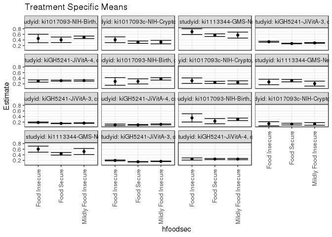

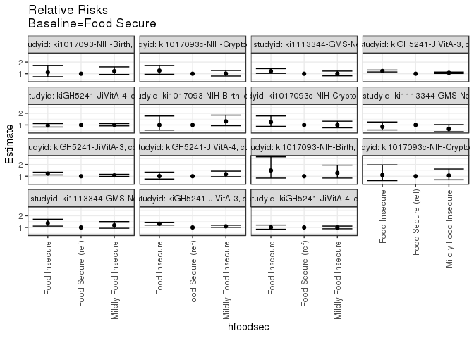

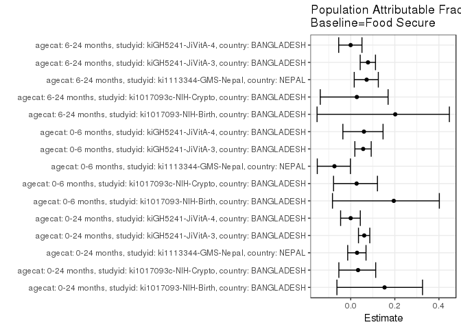

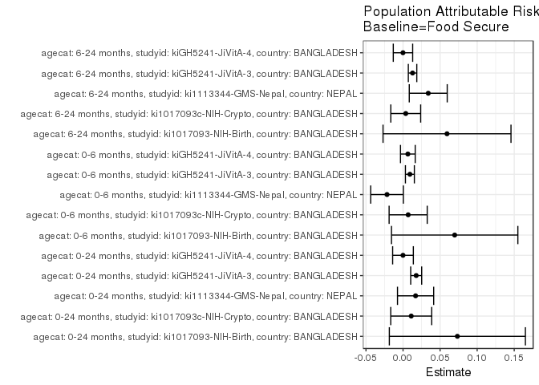

## Results Table

### Parameter: TSM

| agecat | studyid | country | intervention_level | baseline_level | estimate | ci_lower | ci_upper |
| --- | --- | --- | --- | --- | --- | --- | --- |
| 0-24 months | ki1017093-NIH-Birth | BANGLADESH | Food Secure | NA | 0.4042553 | 0.3049688 | 0.5035419 |
| 0-24 months | ki1017093-NIH-Birth | BANGLADESH | Mildly Food Insecure | NA | 0.4938525 | 0.4494585 | 0.5382464 |
| 0-24 months | ki1017093-NIH-Birth | BANGLADESH | Food Insecure | NA | 0.4523810 | 0.3017330 | 0.6030289 |
| 0-24 months | ki1017093c-NIH-Crypto | BANGLADESH | Food Secure | NA | 0.3200883 | 0.2771003 | 0.3630763 |
| 0-24 months | ki1017093c-NIH-Crypto | BANGLADESH | Mildly Food Insecure | NA | 0.3242009 | 0.2621671 | 0.3862347 |
| 0-24 months | ki1017093c-NIH-Crypto | BANGLADESH | Food Insecure | NA | 0.4069767 | 0.3030790 | 0.5108745 |
| 0-24 months | ki1113344-GMS-Nepal | NEPAL | Food Secure | NA | 0.5721040 | 0.5249133 | 0.6192947 |
| 0-24 months | ki1113344-GMS-Nepal | NEPAL | Mildly Food Insecure | NA | 0.5731707 | 0.4660231 | 0.6803183 |
| 0-24 months | ki1113344-GMS-Nepal | NEPAL | Food Insecure | NA | 0.6962025 | 0.5947024 | 0.7977027 |
| 0-24 months | kiGH5241-JiVitA-3 | BANGLADESH | Food Secure | NA | 0.2722980 | 0.2615477 | 0.2830483 |
| 0-24 months | kiGH5241-JiVitA-3 | BANGLADESH | Mildly Food Insecure | NA | 0.2938171 | 0.2809037 | 0.3067305 |
| 0-24 months | kiGH5241-JiVitA-3 | BANGLADESH | Food Insecure | NA | 0.3358699 | 0.3175195 | 0.3542203 |
| 0-24 months | kiGH5241-JiVitA-4 | BANGLADESH | Food Secure | NA | 0.3131313 | 0.2929982 | 0.3332644 |
| 0-24 months | kiGH5241-JiVitA-4 | BANGLADESH | Mildly Food Insecure | NA | 0.3176159 | 0.2934051 | 0.3418267 |
| 0-24 months | kiGH5241-JiVitA-4 | BANGLADESH | Food Insecure | NA | 0.3003636 | 0.2585297 | 0.3421976 |
| 0-6 months | ki1017093-NIH-Birth | BANGLADESH | Food Secure | NA | 0.2872340 | 0.1956911 | 0.3787770 |
| 0-6 months | ki1017093-NIH-Birth | BANGLADESH | Mildly Food Insecure | NA | 0.3765432 | 0.3334320 | 0.4196544 |
| 0-6 months | ki1017093-NIH-Birth | BANGLADESH | Food Insecure | NA | 0.2857143 | 0.1489808 | 0.4224477 |
| 0-6 months | ki1017093c-NIH-Crypto | BANGLADESH | Food Secure | NA | 0.2516556 | 0.2116667 | 0.2916446 |
| 0-6 months | ki1017093c-NIH-Crypto | BANGLADESH | Mildly Food Insecure | NA | 0.2511416 | 0.1936675 | 0.3086156 |
| 0-6 months | ki1017093c-NIH-Crypto | BANGLADESH | Food Insecure | NA | 0.3139535 | 0.2158024 | 0.4121045 |
| 0-6 months | ki1113344-GMS-Nepal | NEPAL | Food Secure | NA | 0.3144208 | 0.2701381 | 0.3587035 |
| 0-6 months | ki1113344-GMS-Nepal | NEPAL | Mildly Food Insecure | NA | 0.2073171 | 0.1194997 | 0.2951345 |
| 0-6 months | ki1113344-GMS-Nepal | NEPAL | Food Insecure | NA | 0.2658228 | 0.1683231 | 0.3633225 |
| 0-6 months | kiGH5241-JiVitA-3 | BANGLADESH | Food Secure | NA | 0.1539972 | 0.1452507 | 0.1627438 |
| 0-6 months | kiGH5241-JiVitA-3 | BANGLADESH | Mildly Food Insecure | NA | 0.1647816 | 0.1544855 | 0.1750778 |
| 0-6 months | kiGH5241-JiVitA-3 | BANGLADESH | Food Insecure | NA | 0.1879125 | 0.1722838 | 0.2035412 |
| 0-6 months | kiGH5241-JiVitA-4 | BANGLADESH | Food Secure | NA | 0.1020171 | 0.0888349 | 0.1151992 |
| 0-6 months | kiGH5241-JiVitA-4 | BANGLADESH | Mildly Food Insecure | NA | 0.1197572 | 0.1017527 | 0.1377617 |
| 0-6 months | kiGH5241-JiVitA-4 | BANGLADESH | Food Insecure | NA | 0.1031390 | 0.0767112 | 0.1295669 |
| 6-24 months | ki1017093-NIH-Birth | BANGLADESH | Food Secure | NA | 0.2345679 | 0.1422056 | 0.3269302 |
| 6-24 months | ki1017093-NIH-Birth | BANGLADESH | Mildly Food Insecure | NA | 0.3000000 | 0.2561333 | 0.3438667 |
| 6-24 months | ki1017093-NIH-Birth | BANGLADESH | Food Insecure | NA | 0.3500000 | 0.2020515 | 0.4979485 |
| 6-24 months | ki1017093c-NIH-Crypto | BANGLADESH | Food Secure | NA | 0.1278539 | 0.0965599 | 0.1591478 |
| 6-24 months | ki1017093c-NIH-Crypto | BANGLADESH | Mildly Food Insecure | NA | 0.1352657 | 0.0886432 | 0.1818882 |
| 6-24 months | ki1017093c-NIH-Crypto | BANGLADESH | Food Insecure | NA | 0.1411765 | 0.0671019 | 0.2152511 |
| 6-24 months | ki1113344-GMS-Nepal | NEPAL | Food Secure | NA | 0.4371981 | 0.3893743 | 0.4850219 |
| 6-24 months | ki1113344-GMS-Nepal | NEPAL | Mildly Food Insecure | NA | 0.5185185 | 0.4096113 | 0.6274258 |
| 6-24 months | ki1113344-GMS-Nepal | NEPAL | Food Insecure | NA | 0.6025641 | 0.4938677 | 0.7112605 |
| 6-24 months | kiGH5241-JiVitA-3 | BANGLADESH | Food Secure | NA | 0.1512093 | 0.1432171 | 0.1592015 |
| 6-24 months | kiGH5241-JiVitA-3 | BANGLADESH | Mildly Food Insecure | NA | 0.1658234 | 0.1554676 | 0.1761793 |
| 6-24 months | kiGH5241-JiVitA-3 | BANGLADESH | Food Insecure | NA | 0.1992995 | 0.1835109 | 0.2150881 |
| 6-24 months | kiGH5241-JiVitA-4 | BANGLADESH | Food Secure | NA | 0.2482190 | 0.2289951 | 0.2674428 |
| 6-24 months | kiGH5241-JiVitA-4 | BANGLADESH | Mildly Food Insecure | NA | 0.2471463 | 0.2249238 | 0.2693687 |
| 6-24 months | kiGH5241-JiVitA-4 | BANGLADESH | Food Insecure | NA | 0.2505478 | 0.2108097 | 0.2902860 |

### Parameter: E(Y)

| agecat | studyid | country | intervention_level | baseline_level | estimate | ci_lower | ci_upper |
| --- | --- | --- | --- | --- | --- | --- | --- |
| 0-24 months | ki1017093-NIH-Birth | BANGLADESH | NA | NA | 0.4775641 | 0.4383415 | 0.5167867 |
| 0-24 months | ki1017093c-NIH-Crypto | BANGLADESH | NA | NA | 0.3311346 | 0.2976093 | 0.3646598 |
| 0-24 months | ki1113344-GMS-Nepal | NEPAL | NA | NA | 0.5890411 | 0.5491031 | 0.6289790 |
| 0-24 months | kiGH5241-JiVitA-3 | BANGLADESH | NA | NA | 0.2900539 | 0.2824242 | 0.2976836 |
| 0-24 months | kiGH5241-JiVitA-4 | BANGLADESH | NA | NA | 0.3130716 | 0.2985240 | 0.3276193 |
| 0-6 months | ki1017093-NIH-Birth | BANGLADESH | NA | NA | 0.3569132 | 0.3192325 | 0.3945938 |
| 0-6 months | ki1017093c-NIH-Crypto | BANGLADESH | NA | NA | 0.2585752 | 0.2273844 | 0.2897660 |
| 0-6 months | ki1113344-GMS-Nepal | NEPAL | NA | NA | 0.2928082 | 0.2558702 | 0.3297463 |
| 0-6 months | kiGH5241-JiVitA-3 | BANGLADESH | NA | NA | 0.1632334 | 0.1570476 | 0.1694192 |
| 0-6 months | kiGH5241-JiVitA-4 | BANGLADESH | NA | NA | 0.1085195 | 0.0986291 | 0.1184098 |
| 6-24 months | ki1017093-NIH-Birth | BANGLADESH | NA | NA | 0.2939002 | 0.2554778 | 0.3323226 |
| 6-24 months | ki1017093c-NIH-Crypto | BANGLADESH | NA | NA | 0.1315068 | 0.1069744 | 0.1560393 |
| 6-24 months | ki1113344-GMS-Nepal | NEPAL | NA | NA | 0.4712042 | 0.4302971 | 0.5121113 |
| 6-24 months | kiGH5241-JiVitA-3 | BANGLADESH | NA | NA | 0.1640564 | 0.1579346 | 0.1701781 |
| 6-24 months | kiGH5241-JiVitA-4 | BANGLADESH | NA | NA | 0.2481375 | 0.2344076 | 0.2618675 |

### Parameter: RR

| agecat | studyid | country | intervention_level | baseline_level | estimate | ci_lower | ci_upper |
| --- | --- | --- | --- | --- | --- | --- | --- |
| 0-24 months | ki1017093-NIH-Birth | BANGLADESH | Food Secure | Food Secure | 1.0000000 | 1.0000000 | 1.000000 |
| 0-24 months | ki1017093-NIH-Birth | BANGLADESH | Mildly Food Insecure | Food Secure | 1.2216350 | 0.9404965 | 1.586813 |
| 0-24 months | ki1017093-NIH-Birth | BANGLADESH | Food Insecure | Food Secure | 1.1190476 | 0.7398510 | 1.692594 |
| 0-24 months | ki1017093c-NIH-Crypto | BANGLADESH | Food Secure | Food Secure | 1.0000000 | 1.0000000 | 1.000000 |
| 0-24 months | ki1017093c-NIH-Crypto | BANGLADESH | Mildly Food Insecure | Food Secure | 1.0128484 | 0.8017129 | 1.279588 |
| 0-24 months | ki1017093c-NIH-Crypto | BANGLADESH | Food Insecure | Food Secure | 1.2714515 | 0.9528451 | 1.696592 |
| 0-24 months | ki1113344-GMS-Nepal | NEPAL | Food Secure | Food Secure | 1.0000000 | 1.0000000 | 1.000000 |
| 0-24 months | ki1113344-GMS-Nepal | NEPAL | Mildly Food Insecure | Food Secure | 1.0018645 | 0.8167149 | 1.228988 |
| 0-24 months | ki1113344-GMS-Nepal | NEPAL | Food Insecure | Food Secure | 1.2169160 | 1.0292306 | 1.438827 |
| 0-24 months | kiGH5241-JiVitA-3 | BANGLADESH | Food Secure | Food Secure | 1.0000000 | 1.0000000 | 1.000000 |
| 0-24 months | kiGH5241-JiVitA-3 | BANGLADESH | Mildly Food Insecure | Food Secure | 1.0790277 | 1.0169981 | 1.144841 |
| 0-24 months | kiGH5241-JiVitA-3 | BANGLADESH | Food Insecure | Food Secure | 1.2334644 | 1.1561159 | 1.315988 |
| 0-24 months | kiGH5241-JiVitA-4 | BANGLADESH | Food Secure | Food Secure | 1.0000000 | 1.0000000 | 1.000000 |
| 0-24 months | kiGH5241-JiVitA-4 | BANGLADESH | Mildly Food Insecure | Food Secure | 1.0143217 | 0.9200368 | 1.118269 |
| 0-24 months | kiGH5241-JiVitA-4 | BANGLADESH | Food Insecure | Food Secure | 0.9592258 | 0.8214626 | 1.120092 |
| 0-6 months | ki1017093-NIH-Birth | BANGLADESH | Food Secure | Food Secure | 1.0000000 | 1.0000000 | 1.000000 |
| 0-6 months | ki1017093-NIH-Birth | BANGLADESH | Mildly Food Insecure | Food Secure | 1.3109282 | 0.9343437 | 1.839294 |
| 0-6 months | ki1017093-NIH-Birth | BANGLADESH | Food Insecure | Food Secure | 0.9947090 | 0.5597400 | 1.767688 |
| 0-6 months | ki1017093c-NIH-Crypto | BANGLADESH | Food Secure | Food Secure | 1.0000000 | 1.0000000 | 1.000000 |
| 0-6 months | ki1017093c-NIH-Crypto | BANGLADESH | Mildly Food Insecure | Food Secure | 0.9979572 | 0.7552895 | 1.318592 |
| 0-6 months | ki1017093c-NIH-Crypto | BANGLADESH | Food Insecure | Food Secure | 1.2475520 | 0.8785238 | 1.771592 |
| 0-6 months | ki1113344-GMS-Nepal | NEPAL | Food Secure | Food Secure | 1.0000000 | 1.0000000 | 1.000000 |
| 0-6 months | ki1113344-GMS-Nepal | NEPAL | Mildly Food Insecure | Food Secure | 0.6593618 | 0.4219482 | 1.030359 |
| 0-6 months | ki1113344-GMS-Nepal | NEPAL | Food Insecure | Food Secure | 0.8454364 | 0.5707537 | 1.252314 |
| 0-6 months | kiGH5241-JiVitA-3 | BANGLADESH | Food Secure | Food Secure | 1.0000000 | 1.0000000 | 1.000000 |
| 0-6 months | kiGH5241-JiVitA-3 | BANGLADESH | Mildly Food Insecure | Food Secure | 1.0700298 | 0.9828741 | 1.164914 |
| 0-6 months | kiGH5241-JiVitA-3 | BANGLADESH | Food Insecure | Food Secure | 1.2202328 | 1.1071549 | 1.344860 |
| 0-6 months | kiGH5241-JiVitA-4 | BANGLADESH | Food Secure | Food Secure | 1.0000000 | 1.0000000 | 1.000000 |
| 0-6 months | kiGH5241-JiVitA-4 | BANGLADESH | Mildly Food Insecure | Food Secure | 1.1738935 | 0.9615786 | 1.433087 |
| 0-6 months | kiGH5241-JiVitA-4 | BANGLADESH | Food Insecure | Food Secure | 1.0109976 | 0.7567197 | 1.350720 |
| 6-24 months | ki1017093-NIH-Birth | BANGLADESH | Food Secure | Food Secure | 1.0000000 | 1.0000000 | 1.000000 |
| 6-24 months | ki1017093-NIH-Birth | BANGLADESH | Mildly Food Insecure | Food Secure | 1.2789474 | 0.8403041 | 1.946565 |
| 6-24 months | ki1017093-NIH-Birth | BANGLADESH | Food Insecure | Food Secure | 1.4921053 | 0.8373585 | 2.658811 |
| 6-24 months | ki1017093c-NIH-Crypto | BANGLADESH | Food Secure | Food Secure | 1.0000000 | 1.0000000 | 1.000000 |
| 6-24 months | ki1017093c-NIH-Crypto | BANGLADESH | Mildly Food Insecure | Food Secure | 1.0579710 | 0.6932345 | 1.614609 |
| 6-24 months | ki1017093c-NIH-Crypto | BANGLADESH | Food Insecure | Food Secure | 1.1042017 | 0.6188736 | 1.970130 |
| 6-24 months | ki1113344-GMS-Nepal | NEPAL | Food Secure | Food Secure | 1.0000000 | 1.0000000 | 1.000000 |
| 6-24 months | ki1113344-GMS-Nepal | NEPAL | Mildly Food Insecure | Food Secure | 1.1860037 | 0.9359216 | 1.502909 |
| 6-24 months | ki1113344-GMS-Nepal | NEPAL | Food Insecure | Food Secure | 1.3782405 | 1.1161031 | 1.701946 |
| 6-24 months | kiGH5241-JiVitA-3 | BANGLADESH | Food Secure | Food Secure | 1.0000000 | 1.0000000 | 1.000000 |
| 6-24 months | kiGH5241-JiVitA-3 | BANGLADESH | Mildly Food Insecure | Food Secure | 1.0966483 | 1.0122572 | 1.188075 |
| 6-24 months | kiGH5241-JiVitA-3 | BANGLADESH | Food Insecure | Food Secure | 1.3180369 | 1.2018495 | 1.445457 |
| 6-24 months | kiGH5241-JiVitA-4 | BANGLADESH | Food Secure | Food Secure | 1.0000000 | 1.0000000 | 1.000000 |
| 6-24 months | kiGH5241-JiVitA-4 | BANGLADESH | Mildly Food Insecure | Food Secure | 0.9956784 | 0.8865779 | 1.118205 |
| 6-24 months | kiGH5241-JiVitA-4 | BANGLADESH | Food Insecure | Food Secure | 1.0093823 | 0.8451196 | 1.205572 |

### Parameter: PAR

| agecat | studyid | country | intervention_level | baseline_level | estimate | ci_lower | ci_upper |
| --- | --- | --- | --- | --- | --- | --- | --- |
| 0-24 months | ki1017093-NIH-Birth | BANGLADESH | Food Secure | NA | 0.0733088 | -0.0184858 | 0.1651034 |
| 0-24 months | ki1017093c-NIH-Crypto | BANGLADESH | Food Secure | NA | 0.0110463 | -0.0165785 | 0.0386710 |
| 0-24 months | ki1113344-GMS-Nepal | NEPAL | Food Secure | NA | 0.0169371 | -0.0074751 | 0.0413493 |
| 0-24 months | kiGH5241-JiVitA-3 | BANGLADESH | Food Secure | NA | 0.0177559 | 0.0103486 | 0.0251631 |
| 0-24 months | kiGH5241-JiVitA-4 | BANGLADESH | Food Secure | NA | -0.0000597 | -0.0140270 | 0.0139076 |
| 0-6 months | ki1017093-NIH-Birth | BANGLADESH | Food Secure | NA | 0.0696791 | -0.0155679 | 0.1549261 |
| 0-6 months | ki1017093c-NIH-Crypto | BANGLADESH | Food Secure | NA | 0.0069196 | -0.0187834 | 0.0326225 |
| 0-6 months | ki1113344-GMS-Nepal | NEPAL | Food Secure | NA | -0.0216126 | -0.0436279 | 0.0004027 |
| 0-6 months | kiGH5241-JiVitA-3 | BANGLADESH | Food Secure | NA | 0.0092362 | 0.0032084 | 0.0152640 |
| 0-6 months | kiGH5241-JiVitA-4 | BANGLADESH | Food Secure | NA | 0.0065024 | -0.0034181 | 0.0164229 |
| 6-24 months | ki1017093-NIH-Birth | BANGLADESH | Food Secure | NA | 0.0593323 | -0.0269960 | 0.1456606 |
| 6-24 months | ki1017093c-NIH-Crypto | BANGLADESH | Food Secure | NA | 0.0036530 | -0.0164960 | 0.0238019 |
| 6-24 months | ki1113344-GMS-Nepal | NEPAL | Food Secure | NA | 0.0340061 | 0.0084021 | 0.0596101 |
| 6-24 months | kiGH5241-JiVitA-3 | BANGLADESH | Food Secure | NA | 0.0128470 | 0.0071353 | 0.0185588 |
| 6-24 months | kiGH5241-JiVitA-4 | BANGLADESH | Food Secure | NA | -0.0000814 | -0.0131646 | 0.0130017 |

### Parameter: PAF

| agecat | studyid | country | intervention_level | baseline_level | estimate | ci_lower | ci_upper |
| --- | --- | --- | --- | --- | --- | --- | --- |
| 0-24 months | ki1017093-NIH-Birth | BANGLADESH | Food Secure | NA | 0.1535056 | -0.0625656 | 0.3256391 |
| 0-24 months | ki1017093c-NIH-Crypto | BANGLADESH | Food Secure | NA | 0.0333588 | -0.0537681 | 0.1132820 |
| 0-24 months | ki1113344-GMS-Nepal | NEPAL | Food Secure | NA | 0.0287536 | -0.0136726 | 0.0694042 |
| 0-24 months | kiGH5241-JiVitA-3 | BANGLADESH | Food Secure | NA | 0.0612157 | 0.0352393 | 0.0864927 |
| 0-24 months | kiGH5241-JiVitA-4 | BANGLADESH | Food Secure | NA | -0.0001906 | -0.0458143 | 0.0434428 |
| 0-6 months | ki1017093-NIH-Birth | BANGLADESH | Food Secure | NA | 0.1952271 | -0.0827160 | 0.4018197 |
| 0-6 months | ki1017093c-NIH-Crypto | BANGLADESH | Food Secure | NA | 0.0267604 | -0.0778767 | 0.1212396 |
| 0-6 months | ki1113344-GMS-Nepal | NEPAL | Food Secure | NA | -0.0738114 | -0.1516244 | -0.0012561 |
| 0-6 months | kiGH5241-JiVitA-3 | BANGLADESH | Food Secure | NA | 0.0565827 | 0.0188016 | 0.0929091 |
| 0-6 months | kiGH5241-JiVitA-4 | BANGLADESH | Food Secure | NA | 0.0599192 | -0.0355796 | 0.1466113 |
| 6-24 months | ki1017093-NIH-Birth | BANGLADESH | Food Secure | NA | 0.2018790 | -0.1526194 | 0.4473483 |
| 6-24 months | ki1017093c-NIH-Crypto | BANGLADESH | Food Secure | NA | 0.0277778 | -0.1380989 | 0.1694781 |
| 6-24 months | ki1113344-GMS-Nepal | NEPAL | Food Secure | NA | 0.0721685 | 0.0159588 | 0.1251675 |
| 6-24 months | kiGH5241-JiVitA-3 | BANGLADESH | Food Secure | NA | 0.0783087 | 0.0429699 | 0.1123426 |
| 6-24 months | kiGH5241-JiVitA-4 | BANGLADESH | Food Secure | NA | -0.0003282 | -0.0544674 | 0.0510314 |